# 一言不合就学R

[商务大数据智能分析](http://xiangyuchang.github.io/course17/index.html) 之 **R5**

Lecture : 常 象 宇  
xiangyuchang@xjtu.edu.cn

2017年4月16日

### 概览

- 统计机器学习的实验设计
- Caret包简介
- 北京市出租车数据案例

### 统计机器学习的实验设计

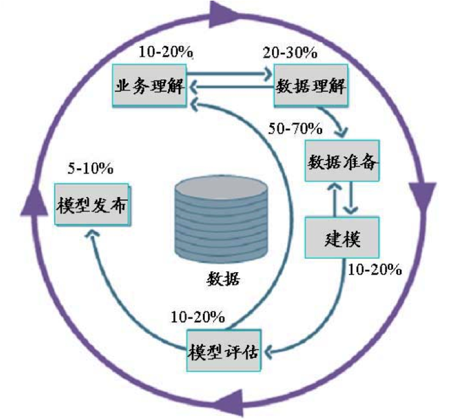

### 统计机器学习的实验设计

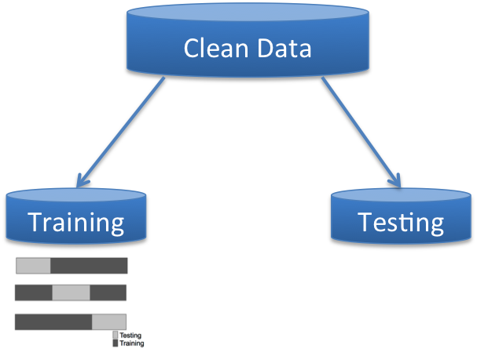

### Caret

[Caret参考手册](http://topepo.github.io/caret/index.html)

- Caret是一个R中统计机器学习算法包的集成平台。里面包含了147个各种不同的统计机器学习方法与模型。
- Caret包自动化的完成数据的交叉验证与参数选择过程。
- Caret包支持平行计算功能，大大提高计算效率。

### Caret

- Data Splitting (Train, Test, Sampling)
- Preprocessing Data (Clear, Standardize, Transform, Impute)
- Training and Testing Approaches (Train and Predict)
- Model Comparison (Cross-validation, Confusion Matrix)

### 北京市出租车数据案例

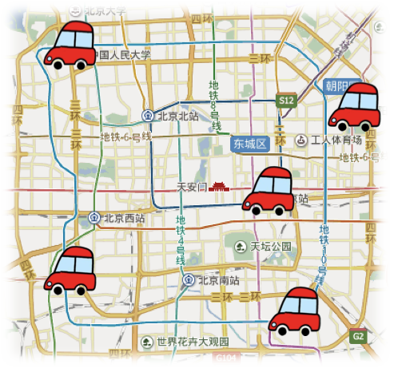

- 哪些状态的出租车在下一时刻更容易非空？
- 哪些指标与出租车下一时刻是否非空相关？
- 我们能够给出出租车下一时刻非空可能性的定量化估计么？

### 原始数据

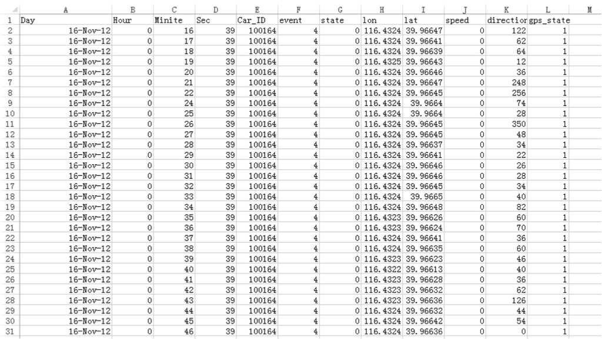

- 样本来源：采用一天的出租车状态数据
- 筛选运营状态：0=空车，1=载客，共计180188条
- 按照五分钟汇总指标，最终数据共包含16887个观测（原因：数据采集不平均)

### 原始数据

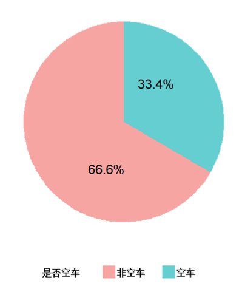

-state:五分钟内出租车是否为空（有载客状态则视为非空）

### 指标设计

1. 上一时刻是否是空车：五分钟内有载客状态则视为载客，否则为空车
2. 速度平均值：五分钟内速度的平均值
3. 速度标准差：五分钟内速度的标准差
4. 是否是早高峰（rush1）：7≤Hour≤9定义为1，否则为0.
5. 是否是晚高峰 （rush2）： 17≤Hour≤20定义为1，否则为0.
6. 所在区域：计算五分钟内经纬度平均值并计算与以下区域的差距，选择最近的区域作为车辆五分钟内所在区域。

### Data

```r
after <- read.csv("final_data.csv")
head(after, 3)
```

```
  Car_ID Hour five state speed_ave speed_sd    disNam rush1 rush2 stateBef
1 100164    0    5     0         0        0 dongcheng FALSE FALSE        0
2 100164    0    6     0         0        0 dongcheng FALSE FALSE        0
3 100164    0    7     0         0        0 dongcheng FALSE FALSE        0
  logspeed_ave logspeed_sd      ave1       sd1 chongwen haidian chaoyang
1            0           0 -2.179164 -2.248029    FALSE   FALSE    FALSE
2            0           0 -2.179164 -2.248029    FALSE   FALSE    FALSE
3            0           0 -2.179164 -2.248029    FALSE   FALSE    FALSE
  dongcheng xicheng xuanwu
1      TRUE   FALSE  FALSE
2      TRUE   FALSE  FALSE
3      TRUE   FALSE  FALSE
```

### Logistic Regression

```r
set.seed(2017) #设计随机数种子

sample <- sample(dim(after)[1],round(0.8*dim(after)[1])) #产生训练样本的编号

trainset <- after[sample,] #构建训练集

testset <- after[-sample,] #构建测试集

fit1 <- glm(state~ave1+sd1+chongwen+haidian+chaoyang+dongcheng
+xicheng+xuanwu+rush1+rush2+stateBef,family="binomial", data = trainset) #逻辑回归

p1 <- predict(fit1,testset) #测试集合进行预测

score1 <- exp(p1)/(1+exp(p1)) #转化成概率

pstate1 <- rep(0, length(p1)) #选择0.5作为阈值

pstate1[score1>=0.5] <- 1 #赋值
```

### Logistic Regression

```r
table(pstate1, testset$state)/length(p1) # 构建混淆矩阵
```

```
pstate1          0          1
      0 0.26887770 0.07047675
      1 0.05537459 0.60527095
```

```r
accuracy1 <- sum(diag(table(pstate1,testset$state)/length(p1))) #正确率

accuracy1
```

```
[1] 0.8741487
```

### Naive Method

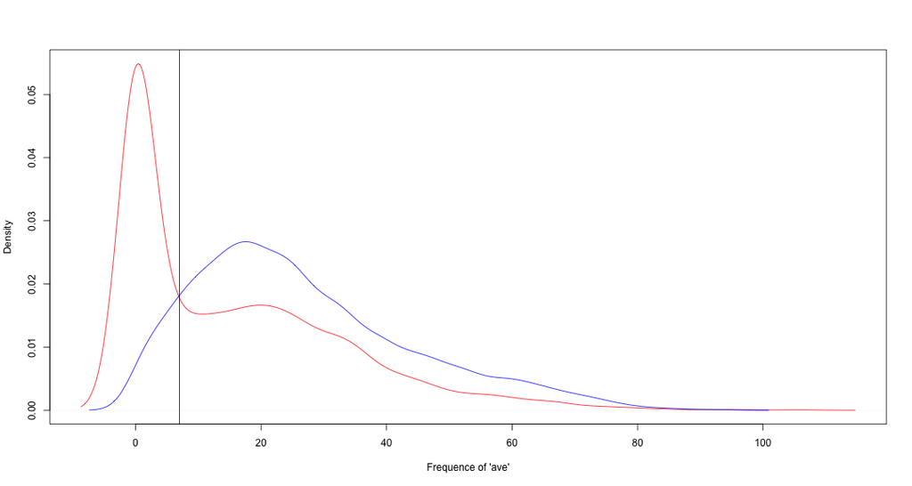

```r
# EDA
plot(density(trainset$speed_ave[trainset$state == 0]),
     col = "red", main = "", xlab = "Frequence of 'ave'")
lines(density(trainset$speed_ave[trainset$state == 1]), col = "blue")
abline(v = 7, col = "black")
```

### Naive Method

```r
pstate2 <- ifelse(testset$speed_ave>7, 1, 0)
table(pstate2, testset$state)/length(pstate2)
```

```
pstate2         0         1
      0 0.1539828 0.0740302
      1 0.1702695 0.6017175
```

```r
accuracy2 <- sum(diag(table(pstate2,testset$state)/length(pstate2)))
accuracy2
```

```
[1] 0.7557003
```

### Caret: Splitting Data

```r
#install.packages("caret", dependencies = c("Depends", "Suggests"))
library("lattice")
library("ggplot2")
library("caret")
set.seed(2017)
inTrain <- createDataPartition(y = after$state, p = 0.8, list = FALSE) #重要的数据划分函数
trainset <- after[inTrain, ]
testset <- after[-inTrain, ]
dim(trainset)
```

```
[1] 13510    20
```

```r
dim(testset)
```

```
[1] 3377   20
```

### Caret: Splitting Data

```r
folds <- createFolds(y = after$state, k = 5, list = TRUE, returnTrain = TRUE)
sapply(folds, length)
```

```
Fold1 Fold2 Fold3 Fold4 Fold5
13509 13510 13510 13510 13509
```

```r
folds$Fold1[1:10]
```

```
 [1]  1  2  3  4  5  6  7  8  9 10
```

– Try `createResample()` and `createTimeSlices()`.

### Caret: Preprocessing Data

```r
mean(after$speed_ave)
```

```
> [1] 22.84735
```

```r
sd(after$speed_ave)
```

```
> [1] 18.18804
```

```r
train_ave <- (trainset$speed_ave - mean(trainset$speed_ave))/sd(trainset$speed_ave)
mean(train_ave)
```

```
> [1] -7.893213e-17
```

```r
sd(train_ave)
```

```
> [1] 1
```

### Caret: Preprocessing Data

```r
preObj <- preProcess(trainset[,-7], method = c("center", "scale")) #数据预处理函数

speed_ave <- predict(preObj, trainset[,-7])$speed_ave

mean(speed_ave)
```

```
[1] -7.893213e-17
```

```r
sd(speed_ave)
```

```
[1] 1
```

– Try other methods, e.g., `impute`, `cox-box trnsform`.

### LR in Caret

```r
fit3 <- train(factor(state)~ave1+sd1+chongwen+haidian
              +chaoyang+dongcheng+xicheng+xuanwu+rush1+rush2+stateBef, data = trainset, method = "glm",family="binomial") #训练函数

pstate3 <- predict(fit3, newdata = testset) #预测函数
```

### LR in Caret

```r
confusionMatrix(pstate3, factor(testset$state)) #混淆矩阵
```

```
Confusion Matrix and Statistics

          Reference
Prediction    0    1
         0  908  238
         1  187 2044

               Accuracy : 0.8741
                 95% CI : (0.8625, 0.8852)
    No Information Rate : 0.6757
    P-Value [Acc > NIR] : < 2e-16

                  Kappa : 0.7163
 Mcnemar's Test P-Value : 0.01529

            Sensitivity : 0.8292
            Specificity : 0.8957
         Pos Pred Value : 0.7923
         Neg Pred Value : 0.9162
             Prevalence : 0.3243
         Detection Rate : 0.2689
   Detection Prevalence : 0.3394
      Balanced Accuracy : 0.8625

       'Positive' Class : 0
```

### CRT in Caret

```r
fit4 <- train(factor(state)~ave1+sd1+chongwen+haidian+chaoyang
              +dongcheng+xicheng+xuanwu+rush1+rush2+stateBef, data = trainset,method = "rpart") #训练函数
pstate4 <- predict(fit4, newdata = testset) #预测函数
```

### CRT in Caret

```r
confusionMatrix(pstate4, factor(testset$state))
```

```
Confusion Matrix and Statistics

          Reference
Prediction    0    1
         0  915  235
         1  180 2047

               Accuracy : 0.8771
                 95% CI : (0.8656, 0.888)
    No Information Rate : 0.6757
    P-Value [Acc > NIR] : < 2.2e-16

                  Kappa : 0.7232
 Mcnemar's Test P-Value : 0.008031

            Sensitivity : 0.8356
            Specificity : 0.8970
         Pos Pred Value : 0.7957
         Neg Pred Value : 0.9192
             Prevalence : 0.3243
         Detection Rate : 0.2710
   Detection Prevalence : 0.3405
      Balanced Accuracy : 0.8663

       'Positive' Class : 0
```

### CRT in Caret

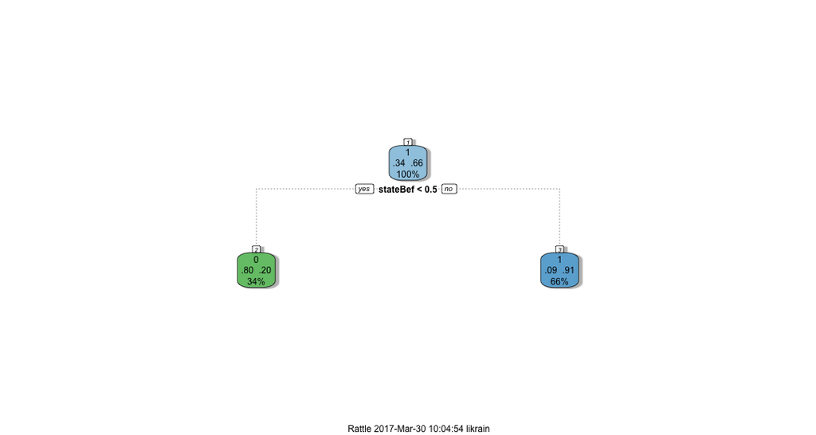

```r
library(rattle)
fancyRpartPlot(fit4$finalModel)
```

Try `plot(fit4$finalModel)`

### Bagging in Caret

```r
fit5 <- train(factor(state)~ave1+sd1+chongwen+haidian+chaoyang
              +dongcheng+xicheng+xuanwu+rush1+rush2+stateBef, data = trainset, method = "treebag")
pstate5 <- predict(fit5, newdata = testset)
```

### Bagging in Caret

```r
confusionMatrix(pstate5, factor(testset$state))
```

```
Confusion Matrix and Statistics

          Reference
Prediction    0    1
         0  832  230
         1  263 2052

               Accuracy : 0.854
                 95% CI : (0.8416, 0.8658)
    No Information Rate : 0.6757
    P-Value [Acc > NIR] : <2e-16

                  Kappa : 0.6642
 Mcnemar's Test P-Value : 0.1495

            Sensitivity : 0.7598
            Specificity : 0.8992
         Pos Pred Value : 0.7834
         Neg Pred Value : 0.8864
             Prevalence : 0.3243
         Detection Rate : 0.2464
   Detection Prevalence : 0.3145
      Balanced Accuracy : 0.8295

       'Positive' Class : 0
```

```r
# Boosting
fit6 <- train(factor(state)~ave1+sd1+chongwen+haidian+chaoyang
              +dongcheng+xicheng+xuanwu+rush1+rush2+stateBef, data = trainset, method = "gam")
pstate6 <- predict(fit6, newdata = testset)
```

```r
confusionMatrix(pstate6, factor(testset$state))
```

```
Confusion Matrix and Statistics

          Reference
Prediction    0    1
         0  918  249
         1  177 2033

               Accuracy : 0.8739
                 95% CI : (0.8622, 0.8849)
    No Information Rate : 0.6757
    P-Value [Acc > NIR] : < 2.2e-16

                  Kappa : 0.717
 Mcnemar's Test P-Value : 0.0005818

            Sensitivity : 0.8384
            Specificity : 0.8909
         Pos Pred Value : 0.7866
         Neg Pred Value : 0.9199
             Prevalence : 0.3243
         Detection Rate : 0.2718
   Detection Prevalence : 0.3456
      Balanced Accuracy : 0.8646

       'Positive' Class : 0
```

### Random Forest in Caret

```r
# Random Forest
fit7 <- train(factor(state)~ave1+sd1+chongwen+haidian+chaoyang
              +dongcheng+xicheng+xuanwu+rush1+rush2+stateBef, data = trainset, method = "rf")
pstate7 <- predict(fit7, newdata = testset)
```

### Random Forest in Caret

```r
confusionMatrix(pstate7, factor(testset$state))
```

```
Confusion Matrix and Statistics

          Reference
Prediction    0    1
         0  916  236
         1  179 2046

               Accuracy : 0.8771
                 95% CI : (0.8656, 0.888)
    No Information Rate : 0.6757
    P-Value [Acc > NIR] : < 2.2e-16

                  Kappa : 0.7233
 Mcnemar's Test P-Value : 0.005979

            Sensitivity : 0.8365
            Specificity : 0.8966
         Pos Pred Value : 0.7951
         Neg Pred Value : 0.9196
             Prevalence : 0.3243
         Detection Rate : 0.2712
   Detection Prevalence : 0.3411
      Balanced Accuracy : 0.8666

       'Positive' Class : 0
```

### Ensemble learning in Caret

```r
combPre <- data.frame(pstate3, pstate4, pstate5, pstate6, pstate7, state = testset$state) #集成
combfit <- train(factor(state)~., method = "gam", data = combPre)
combpstate <- predict(combfit, newdata = testset)
```

### Ensenble learning in Caret

```r
confusionMatrix(combpstate, factor(testset$state))
```

```
Confusion Matrix and Statistics

          Reference
Prediction    0    1
         0  914  235
         1  181 2047

               Accuracy : 0.8768
                 95% CI : (0.8653, 0.8877)
    No Information Rate : 0.6757
    P-Value [Acc > NIR] : < 2.2e-16

                  Kappa : 0.7225
 Mcnemar's Test P-Value : 0.009362

            Sensitivity : 0.8347
            Specificity : 0.8970
         Pos Pred Value : 0.7955
         Neg Pred Value : 0.9188
             Prevalence : 0.3243
         Detection Rate : 0.2707
   Detection Prevalence : 0.3402
      Balanced Accuracy : 0.8659

       'Positive' Class : 0
```

**Thank you**

[figure not shown]